# Final Assignment Part 2

Arash Heidarzadeh Naeini u3236906

2025-05-06

# 1. Dataset Justification

## Source URL

The car datasets used in this analysis were obtained from Kaggle, specifically from the collection of car price datasets available at: https://www.kaggle.com/datasets/nehalbirla/vehicle-dataset-from-cardekho

## Dataset Description

The dataset consists of four related CSV files containing information about used cars in the Indian market, primarily from the CarDekho platform:

1. `car details v4.csv` - Contains detailed car specifications (2059 rows, 20 columns)
2. `car data.csv` - Includes basic car information with pricing (301 rows, 9 columns)
3. `CAR DETAILS FROM CAR DEKHO.csv` - Features car details from the Car Dekho platform (4340 rows, 8 columns)
4. `Car details v3.csv` - Provides extended car details (8128 rows, 13 columns)

These datasets collectively contain comprehensive information about various car attributes including make, model, year, price, mileage, engine specifications, and more.

## Justification for Dataset Selection

This dataset was selected for several compelling reasons:

1. **Practical Relevance**: The used car market represents a significant sector with direct real-world applications where predictive models can provide tangible value.
2. **Multiple Related Files**: The dataset meets the requirement of having multiple related CSV files that can be joined to create a more comprehensive analysis.
3. **Diverse Features**: The collection contains a rich variety of numerical, categorical, and textual features that allow for sophisticated modeling techniques.
4. **Predictive Potential**: The various car attributes (age, mileage, specifications) provide strong potential predictors for car prices, making it well-suited for regression analysis.
5. **Data Quality**: The datasets contain a substantial number of records with a good balance of features, allowing for robust model development and validation.
6. **Business Value**: Predicting car prices accurately has significant economic value for various stakeholders including dealers, insurance companies, and individual buyers/sellers.

# 2. Implementation Overview

## Loading Required Libraries

```r
# Function to install and load packages if not already installed
install_and_load <- function(packages) {
  for (package in packages) {
    if (!require(package, character.only = TRUE, quietly = TRUE)) {
      message(paste("Installing package:", package))
      install.packages(package, dependencies = TRUE, repos = "https://cran.rstudio.com/")
      if (!require(package, character.only = TRUE, quietly = TRUE)) {
        warning(paste("Package", package, "couldn't be installed. Some functionality may be limited."))
      }
    } else {
      message(paste("Package", package, "is already loaded"))
    }
  }
}

# Define necessary packages
packages <- c(
  "tidyverse",    # For data manipulation and visualization
  "readr",        # For reading CSV files
  "dplyr",        # For data manipulation
  "tidyr",        # For data tidying
  "ggplot2",      # For data visualization
  "caret",        # For machine learning functions
  "corrplot",     # For correlation visualization
  "car",          # For VIF calculation
  "knitr",        # For nicer table outputs
  "kableExtra"    # For enhancing table appearance
)

# Install and load all packages
install_and_load(packages)
```

## Importing Data

```r
# Import all datasets
car_details_v4 <- read_csv("car details v4.csv")
car_data <- read_csv("car data.csv")
car_dekho <- read_csv("CAR DETAILS FROM CAR DEKHO.csv")
car_details_v3 <- read_csv("Car details v3.csv")

# Check dimensions of each dataset
cat("Dimensions of car_details_v4:", dim(car_details_v4), "\n")
```

```
## Dimensions of car_details_v4: 2059 20
```

```r
cat("Dimensions of car_data:", dim(car_data), "\n")
```

```
## Dimensions of car_data: 301 9
```

```r
cat("Dimensions of car_dekho:", dim(car_dekho), "\n")
```

```
## Dimensions of car_dekho: 4340 8
```

```r
cat("Dimensions of car_details_v3:", dim(car_details_v3), "\n")
```

```
## Dimensions of car_details_v3: 8128 13
```

```r
# Display the first few rows of the first dataset as a sample
head(car_details_v4, 2) %>%
  kable() %>%
  kable_styling(bootstrap_options = c("striped", "hover", "condensed"), font_size = 10) %>%
  scroll_box(width = "100%")
```

| Make | Model | Price | Year | Kilometer | Fuel Type | Transmission | Location | Color | Owner | Seller Type | Engine | Max Power | Max Torque | Drivetrain | Length | Width | Height | Seating Capacity | Fuel Tank Capacity |
| --- | --- | --- | --- | --- | --- | --- | --- | --- | --- | --- | --- | --- | --- | --- | --- | --- | --- | --- | --- |
| Honda | Amaze 1.2 VX i-VTEC | 505000 | 2017 | 87150 | Petrol | Manual | Pune | Grey | First | Corporate | 1198 cc | 87 bhp @ 6000 rpm | 109 Nm @ 4500 rpm | FWD | 3990 | 1680 | 1505 | 5 | 35 |
| Maruti Suzuki | Swift DZire VDI | 450000 | 2014 | 75000 | Diesel | Manual | Ludhiana | White | Second | Individual | 1248 cc | 74 bhp @ 4000 rpm | 190 Nm @ 2000 rpm | FWD | 3995 | 1695 | 1555 | 5 | 42 |

## Data Wrangling and Merging

The data wrangling process includes standardizing column names across datasets, cleaning and transforming variables, and merging the datasets to create a comprehensive dataset for analysis.

```r
# Standardize and clean car_details_v4
car_details_v4_clean <- car_details_v4 %>%
  rename(
    make = Make,
    model = Model,
    price = Price,
    year = Year,
    km_driven = Kilometer,
    fuel_type = `Fuel Type`,
    transmission = Transmission,
    location = Location,
    color = Color,
    owner = Owner,
    seller_type = `Seller Type`,
    engine_cc = Engine,
    max_power = `Max Power`,
    max_torque = `Max Torque`
  ) %>%
  # Extract numeric values and create derived features
  mutate(
    engine_size = as.numeric(str_extract(engine_cc, "\\d+")),
    car_age = 2025 - year,
    power_value = as.numeric(str_extract(max_power, "\\d+\\.?\\d*")),
    price = as.numeric(price),
    km_driven = as.numeric(km_driven),
    source = "car_details_v4",
    # Create a full name field for potential matching
    full_name = paste(make, model)
  )

# Standardize and clean car_data
car_data_clean <- car_data %>%
  rename(
    model = Car_Name,
    year = Year,
    price = Selling_Price,
    market_price = Present_Price,
    km_driven = Kms_Driven,
    fuel_type = Fuel_Type,
    seller_type = Seller_Type,
    transmission = Transmission,
    owner_num = Owner
  ) %>%
  mutate(
    car_age = 2025 - year,
    # Convert price to same scale (assuming car_data prices are in lakhs)
    price = price * 100000,  # Convert lakhs to INR
    market_price = market_price * 100000,  # Convert lakhs to INR
    source = "car_data",
    # Create make field based on first word of model
    make = word(model, 1),
    # Create a full name field for potential matching
    full_name = model,
    # Standardize owner to match other datasets
    owner = case_when(
      owner_num == 0 ~ "First Owner",
      owner_num == 1 ~ "Second Owner",
      owner_num == 3 ~ "Third Owner",
      TRUE ~ paste(owner_num + 1, "Owner")
    )
  ) %>%
  select(-owner_num)  # Remove redundant column

# Standardize and clean car_dekho
car_dekho_clean <- car_dekho %>%
  rename(
    full_name = name,
    year = year,
    price = selling_price,
    km_driven = km_driven,
    fuel_type = fuel,
    seller_type = seller_type,
    transmission = transmission,
    owner = owner
  ) %>%
  mutate(
    price = as.numeric(price),
    km_driven = as.numeric(km_driven),
    car_age = 2025 - year,
    source = "car_dekho",
    # Extract make/model from name where possible
    make = word(full_name, 1),
    model = word(full_name, 2, -1)
  )

# Standardize and clean car_details_v3
car_details_v3_clean <- car_details_v3 %>%
  rename(
    full_name = name,
    year = year,
    price = selling_price,
    km_driven = km_driven,
    fuel_type = fuel,
    seller_type = seller_type,
    transmission = transmission,
    owner = owner
  ) %>%
  # Extract numeric values and create derived features
  mutate(
    engine_size = as.numeric(str_extract(engine, "\\d+")),
    mileage_value = as.numeric(str_extract(mileage, "\\d+\\.?\\d*")),
    car_age = 2025 - as.numeric(year),
    power_value = as.numeric(str_extract(max_power, "\\d+\\.?\\d*")),
    price = as.numeric(price),
    km_driven = as.numeric(km_driven),
    source = "car_details_v3",
    # Extract make/model from name where possible
    make = word(full_name, 1),
    model = word(full_name, 2, -1)
  )

# Select common important columns for each dataset
common_columns <- c("make", "model", "full_name", "year", "price", "km_driven",
                   "fuel_type", "transmission", "owner", "seller_type",
                   "car_age", "source")

# Create a base combined dataset with common columns
car_details_v4_base <- car_details_v4_clean %>% select(all_of(common_columns))
car_data_base <- car_data_clean %>% select(all_of(common_columns))
car_dekho_base <- car_dekho_clean %>% select(all_of(common_columns))
car_details_v3_base <- car_details_v3_clean %>% select(all_of(common_columns))

# Combine all datasets
combined_cars <- bind_rows(
  car_details_v4_base,
  car_data_base,
  car_dekho_base,
  car_details_v3_base
)

# Create a single additional features dataframe with all supplementary data
additional_features <- bind_rows(
  # From car_details_v4
  car_details_v4_clean %>%
    select(full_name, year, engine_size, power_value, source) %>%
    mutate(dataset = "v4"),

  # From car_data
  car_data_clean %>%
    select(full_name, year, market_price, source) %>%
    mutate(dataset = "car_data"),

  # From car_details_v3
  car_details_v3_clean %>%
    select(full_name, year, engine_size, power_value,
           mileage = mileage_value, seats, source) %>%
    mutate(dataset = "v3")
)

# Create a function to get the first non-NA value for each group
first_non_na <- function(x) {
  non_na <- x[!is.na(x)]
  if(length(non_na) > 0) return(non_na[1])
  return(NA)
}

# Aggregate additional features by taking first non-NA value for each car
aggregated_features <- additional_features %>%
  group_by(full_name, year) %>%
  summarize(
    engine_size = first_non_na(engine_size),
    power_value = first_non_na(power_value),
    mileage = first_non_na(mileage),
    seats = first_non_na(seats),
    market_price = first_non_na(market_price),
    .groups = 'drop'
  )

# Join the aggregated features to the combined dataset
complete_cars <- left_join(combined_cars, aggregated_features, by = c("full_name", "year"))

# Clean up categorical variables and standardize
complete_cars <- complete_cars %>%
  mutate(
    fuel_type = as.factor(fuel_type),
    transmission = as.factor(transmission),
    owner = as.factor(owner),
    seller_type = as.factor(seller_type),
    brand = make
  )

# Print stats about the consolidated dataset
cat("Number of rows in consolidated dataset:", nrow(complete_cars), "\n")
```

```
## Number of rows in consolidated dataset: 14828
```

```r
cat("Number of columns in consolidated dataset:", ncol(complete_cars), "\n")
```

```
## Number of columns in consolidated dataset: 18
```

```r
# Remove duplicates
unique_cars <- complete_cars %>%
  distinct(full_name, year, price, .keep_all = TRUE)

cat("Number of rows after removing duplicates:", nrow(unique_cars), "\n")
```

```
## Number of rows after removing duplicates: 11967
```

```r
# Handle missing values for key features
cleaned_cars <- unique_cars %>%
  # Only keep rows with valid price and km_driven
  filter(!is.na(price) & price > 0) %>%
  filter(!is.na(km_driven) & km_driven > 0)

# Handle missing values using group medians
# First for engine size
cleaned_cars <- cleaned_cars %>%
  group_by(make) %>%
  mutate(engine_size = ifelse(is.na(engine_size),
                            median(engine_size, na.rm = TRUE),
                            engine_size)) %>%
  ungroup()

# Then for power value
cleaned_cars <- cleaned_cars %>%
  group_by(make) %>%
  mutate(power_value = ifelse(is.na(power_value),
                             median(power_value, na.rm = TRUE),
                             power_value)) %>%
  ungroup()

# Calculate bounds for outlier removal
# For price
Q1_price <- quantile(cleaned_cars$price, 0.25, na.rm = TRUE)
Q3_price <- quantile(cleaned_cars$price, 0.75, na.rm = TRUE)
IQR_price <- Q3_price - Q1_price
lower_bound_price <- Q1_price - 1.5 * IQR_price
upper_bound_price <- Q3_price + 1.5 * IQR_price

# For km_driven
Q1_km <- quantile(cleaned_cars$km_driven, 0.25, na.rm = TRUE)
Q3_km <- quantile(cleaned_cars$km_driven, 0.75, na.rm = TRUE)
IQR_km <- Q3_km - Q1_km
lower_bound_km <- Q1_km - 1.5 * IQR_km
upper_bound_km <- Q3_km + 1.5 * IQR_km

# Apply outlier removal
final_cars <- cleaned_cars %>%
  filter(price >= lower_bound_price & price <= upper_bound_price) %>%
  filter(km_driven >= lower_bound_km & km_driven <= upper_bound_km)

cat("Original cleaned data rows:", nrow(cleaned_cars), "\n")
```

```
## Original cleaned data rows: 11966
```

```r
cat("After outlier removal:", nrow(final_cars), "\n")
```

```
## After outlier removal: 10522
```

```r
cat("Removed", nrow(cleaned_cars) - nrow(final_cars), "outliers\n")
```

```
## Removed 1444 outliers
```

```r
# Finalize the dataset by selecting the most important columns
complete_cars <- final_cars %>%
  select(
    brand, model, full_name, year, price, km_driven, fuel_type, transmission,
    owner, seller_type, car_age, engine_size, power_value,
    mileage, seats, source
  )

# Get summary of final dataset
summary(complete_cars)
```

```
##     brand              model            full_name              year
##  Length:10522       Length:10522       Length:10522       Min.   :1983
##  Class :character   Class :character   Class :character   1st Qu.:2011
##  Mode  :character   Mode  :character   Mode  :character   Median :2014
##                                                           Mean   :2014
##                                                           3rd Qu.:2017
##                                                           Max.   :2022
##
##      price           km_driven          fuel_type       transmission
##  Min.   :  10000   Min.   :     1   Petrol   :5259   Automatic: 910
##  1st Qu.: 240000   1st Qu.: 35950   Diesel   :5054   Manual   :9612
##  Median : 400000   Median : 60000   CNG      : 141
##  Mean   : 453467   Mean   : 65240   LPG      :  61
##  3rd Qu.: 620000   3rd Qu.: 90000   Electric :   4
##  Max.   :1375000   Max.   :172000   CNG + CNG:   1
##                                     (Other)  :   2
##                   owner                       seller_type      car_age
##  First Owner         :5742   Commercial Registration:   5   Min.   : 3.00
##  Second Owner        :2527   Corporate              :  24   1st Qu.: 8.00
##  First               :1044   Dealer                 :1321   Median :11.00
##  Third Owner         : 702   Individual             :9117   Mean   :11.47
##  Second              : 238   Trustmark Dealer       :  55   3rd Qu.:14.00
##  Fourth & Above Owner: 211                                  Max.   :42.00
##  (Other)             :  58
##   engine_size    power_value        mileage          seats
##  Min.   : 624   Min.   :  0.00   Min.   : 0.00   Min.   : 2.000
##  1st Qu.:1197   1st Qu.: 69.00   1st Qu.:17.01   1st Qu.: 5.000
##  Median :1248   Median : 82.00   Median :19.70   Median : 5.000
##  Mean   :1388   Mean   : 85.92   Mean   :19.76   Mean   : 5.374
##  3rd Qu.:1498   3rd Qu.: 98.60   3rd Qu.:22.70   3rd Qu.: 5.000
##  Max.   :3498   Max.   :272.00   Max.   :33.44   Max.   :14.000
##  NA's   :259    NA's   :259      NA's   :3067    NA's   :3067
##     source
##  Length:10522
##  Class :character
##  Mode  :character
##
##
##
##
```

## Exploratory Data Analysis

In this section, we’ll explore the key relationships in our data through targeted visualizations that focus on understanding the factors that influence car prices.

### Price Distribution Analysis

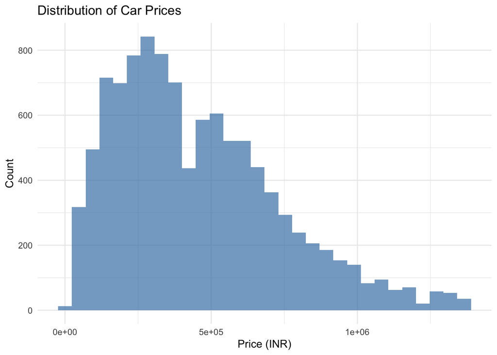

```r
# Price distribution
p_price_dist <- ggplot(complete_cars, aes(x = price)) +
  geom_histogram(bins = 30, fill = "steelblue", alpha = 0.7) +
  labs(title = "Distribution of Car Prices",
       x = "Price (INR)",
       y = "Count") +
  theme_minimal()

# Log transformation of price for better visualization
p_log_price <- ggplot(complete_cars, aes(x = log10(price))) +
  geom_histogram(bins = 30, fill = "steelblue", alpha = 0.7) +
  labs(title = "Distribution of Log10 Car Prices",
       x = "Log10(Price)",
       y = "Count") +
  theme_minimal()

# Display plots
p_price_dist
```

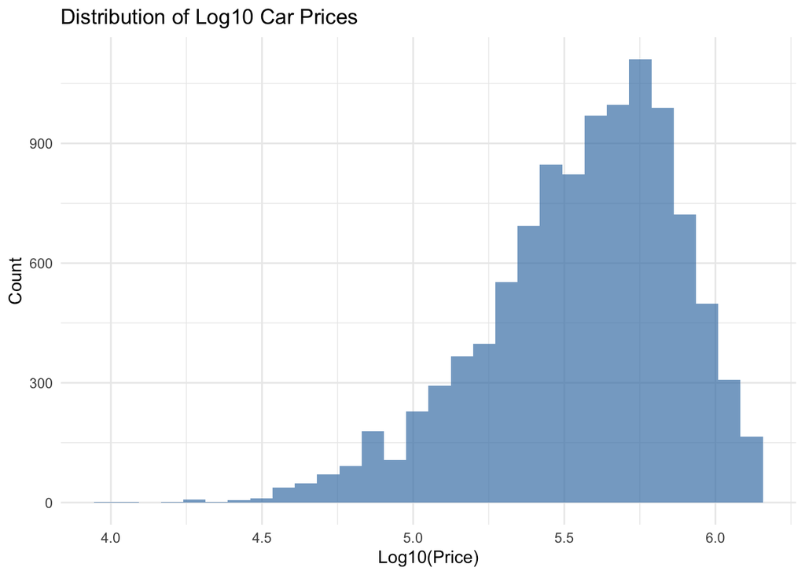

```r
p_log_price
```

**Interpretation:** The price distribution is heavily right-skewed, with a large number of cars in the lower price ranges and fewer in the higher price ranges. This is typical of used car markets where most vehicles are in the affordable range. The log transformation provides a more normal distribution, suggesting that a log transformation of the price variable may be appropriate for our regression modeling.

### Car Age and Price Relationship

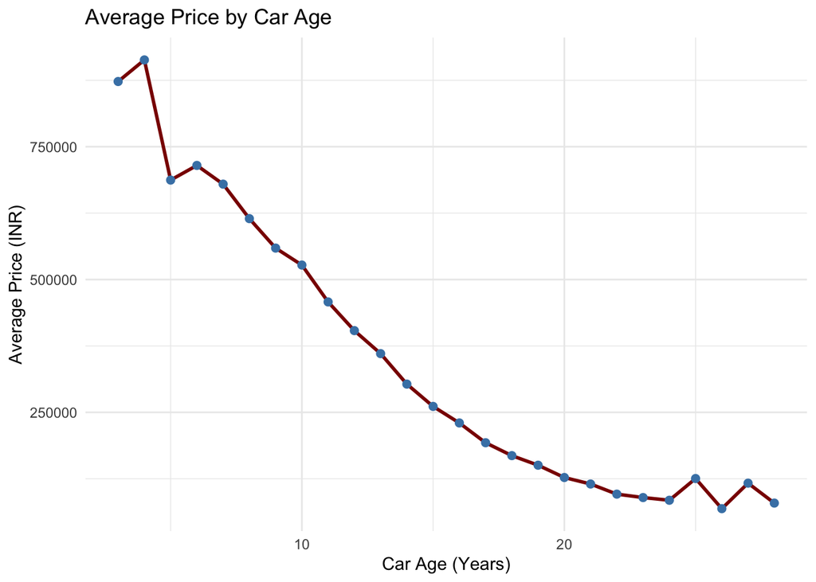

```r
# Process data for visualization
avg_price_by_age <- complete_cars %>%
  group_by(car_age) %>%
  summarise(
    avg_price = mean(price, na.rm = TRUE),
    count = n(),
    .groups = "drop"
  ) %>%
  filter(count >= 10)  # Only include ages with sufficient data

# Line plot with average price by car age
ggplot(avg_price_by_age, aes(x = car_age, y = avg_price)) +
  geom_line(color = "darkred", linewidth = 1) +
  geom_point(color = "steelblue", size = 2) +
  labs(title = "Average Price by Car Age",
       x = "Car Age (Years)",
       y = "Average Price (INR)") +
  theme_minimal()
```

**Interpretation:** There is a clear negative relationship between car age and price. Newer cars command significantly higher prices, with a rapid initial depreciation in the first few years followed by a more gradual decline as vehicles age. This pattern is consistent with the well-known depreciation curve in the automotive industry.

### Brand Analysis

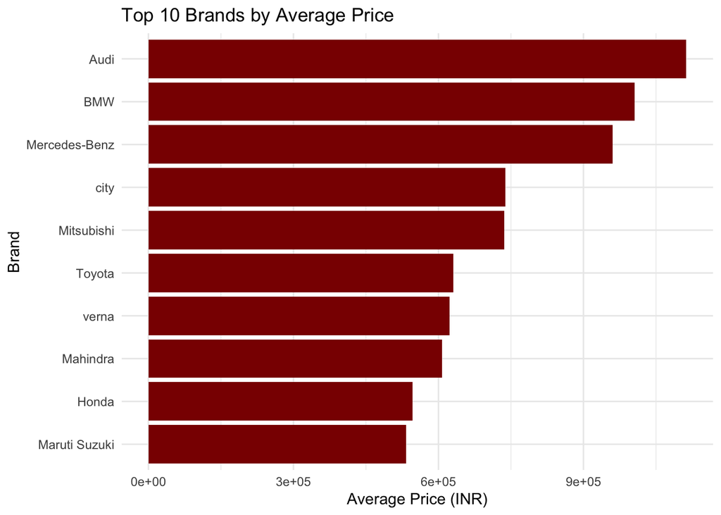

```r
# Brand statistics
brand_stats <- complete_cars %>%
  group_by(brand) %>%
  summarise(
    count = n(),
    avg_price = mean(price, na.rm = TRUE),
    .groups = "drop"
  ) %>%
  arrange(desc(count))

# Top brands by average price
top_brands_by_price <- brand_stats %>%
  filter(count >= 10) %>%
  arrange(desc(avg_price)) %>%
  head(10)

ggplot(top_brands_by_price, aes(x = reorder(brand, avg_price), y = avg_price)) +
  geom_bar(stat = "identity", fill = "darkred") +
  coord_flip() +
  labs(title = "Top 10 Brands by Average Price",
       x = "Brand",
       y = "Average Price (INR)") +
  theme_minimal()
```

**Interpretation:** There is significant variation in average prices across car brands. Luxury brands like Mercedes-Benz, BMW, and Audi command the highest average prices, which is expected given their market positioning. This suggests that brand is likely to be an important predictor in our model.

### Effect of Categorical Variables on Price

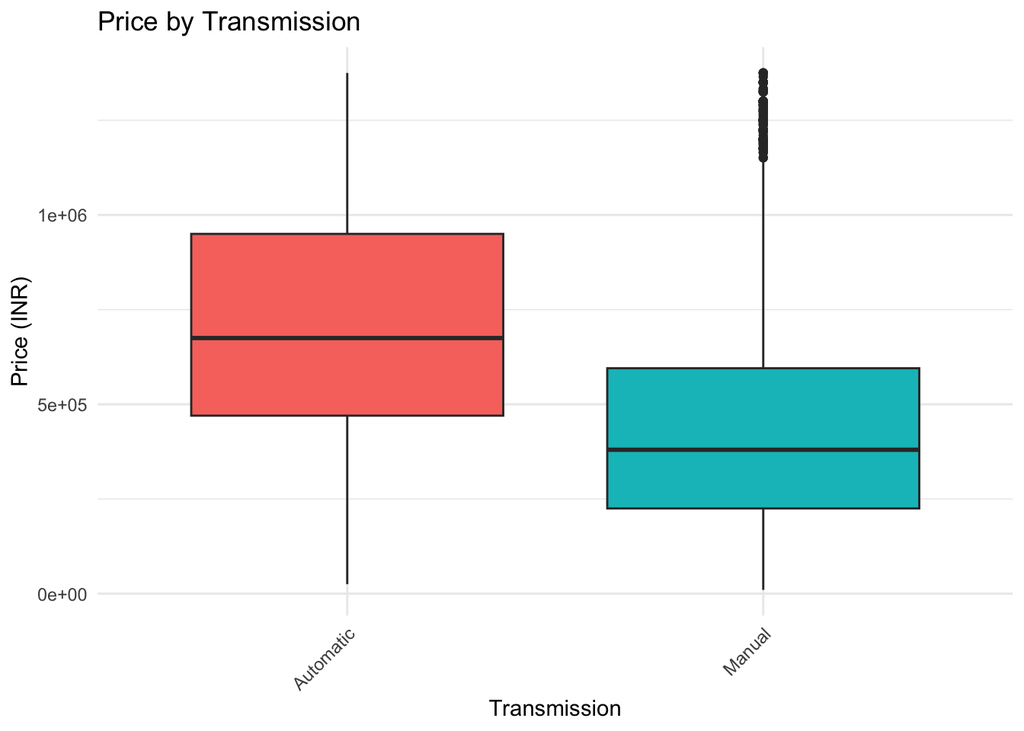

```r
# Function to create boxplot of price by categorical variable
create_boxplot <- function(data, cat_var, title, x_label) {
  # Convert string to symbol for proper evaluation
  var_sym <- sym(cat_var)

  ggplot(data, aes(x = !!var_sym, y = price, fill = !!var_sym)) +
    geom_boxplot() +
    labs(title = title,
         x = x_label,
         y = "Price (INR)") +
    theme_minimal() +
    theme(axis.text.x = element_text(angle = 45, hjust = 1),
          legend.position = "none")
}

# Create boxplots for transmission and fuel type
create_boxplot(complete_cars, "transmission", "Price by Transmission", "Transmission")
```

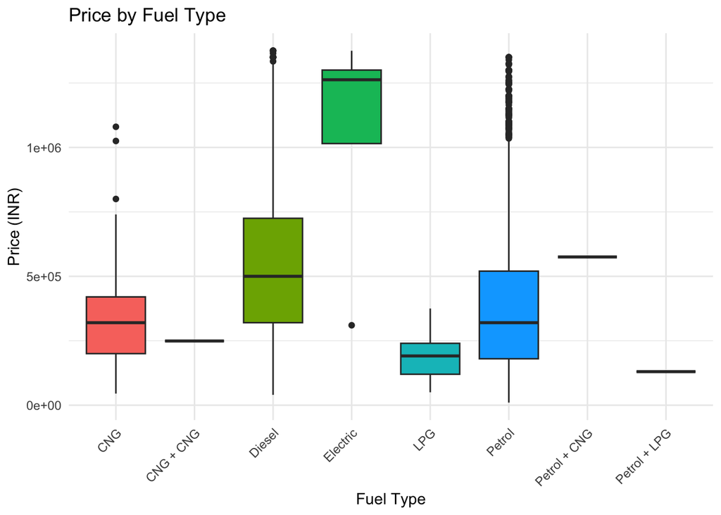

```r
create_boxplot(complete_cars, "fuel_type", "Price by Fuel Type", "Fuel Type")
```

**Interpretation:** - **Transmission:** Automatic transmission vehicles generally have higher prices compared to manual transmission vehicles. This reflects consumer preferences and the typically higher initial cost of automatic transmissions. - **Fuel Type:** There are noticeable price differences across fuel types. Diesel vehicles often command higher prices than petrol vehicles, possibly due to their better fuel efficiency and longer engine life, despite higher maintenance costs.

### Correlation Analysis

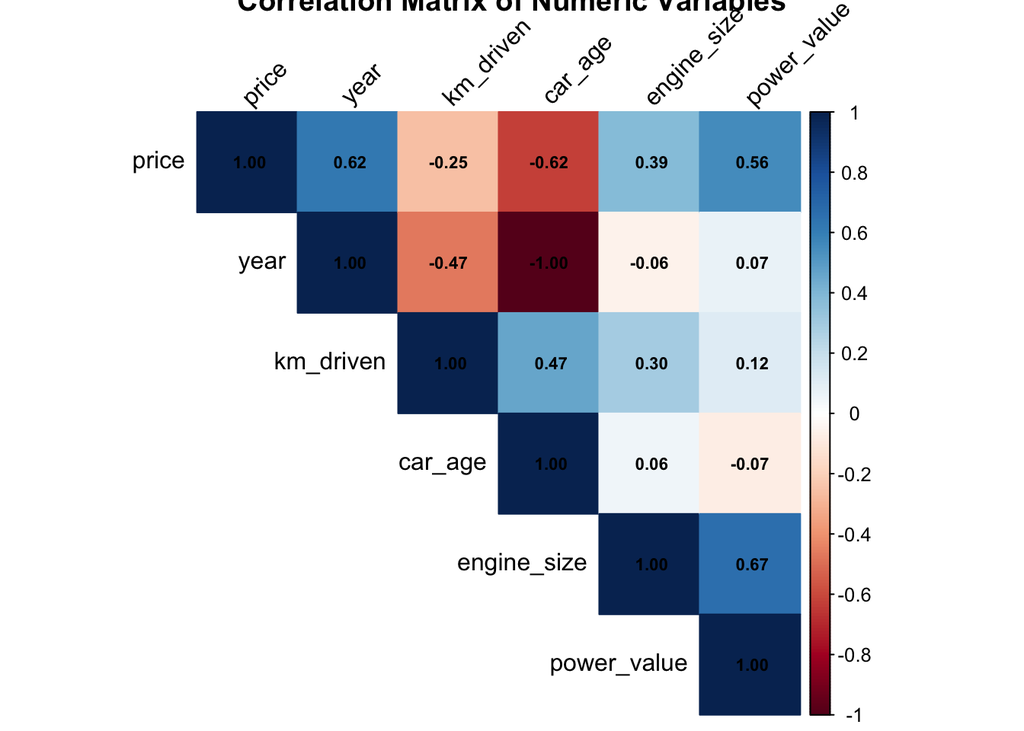

```r
# Select numeric variables for correlation analysis
numeric_vars <- complete_cars %>%
  select(price, year, km_driven, car_age, engine_size, power_value) %>%
  drop_na()

# Calculate correlation matrix
correlation_matrix <- cor(numeric_vars, use = "complete.obs")

# Display correlation matrix as a heatmap
corrplot(correlation_matrix, method = "color", type = "upper",
         tl.col = "black", tl.srt = 45,
         title = "Correlation Matrix of Numeric Variables",
         addCoef.col = "black", number.cex = 0.7)
```

```r
# Print correlation with price
cor_with_price <- correlation_matrix[1, ]
print("Correlation with price:")
```

```
## [1] "Correlation with price:"
```

```r
print(sort(cor_with_price, decreasing = TRUE))
```

```
##       price        year power_value engine_size   km_driven     car_age
##   1.0000000   0.6201553   0.5573243   0.3893563  -0.2535930  -0.6201553
```

**Interpretation:** The correlation analysis reveals several important relationships: - There is a strong positive correlation between price and year (and a corresponding negative correlation with car age). - Engine size and power value show moderate positive correlations with price. - Kilometers driven has a moderate negative correlation with price. - These correlations align with our intuitive understanding of car valuation factors and suggest these variables will be useful in our predictive model.

## Predictive Modeling

Now we’ll build multiple regression models to predict car prices based on the features we’ve analyzed.

```r
# Prepare data for modeling
set.seed(123) # For reproducibility

# Create log price variable for better model fit
complete_cars$log_price <- log10(complete_cars$price)

# Select features for modeling
model_df <- complete_cars %>%
  # Select necessary columns
  select(log_price, price, car_age, km_driven, fuel_type, transmission,
         brand, engine_size, power_value) %>%
  # Remove rows with NA in key variables
  filter(!is.na(engine_size) & !is.na(power_value) &
           !is.na(car_age) & !is.na(km_driven)) %>%
  # Ensure categorical variables are factors
  mutate(
    fuel_type = as.factor(fuel_type),
    transmission = as.factor(transmission),
    brand = as.factor(brand)
  )

# Handle brand variable - group less frequent brands
brand_counts <- table(model_df$brand)
significant_brands <- names(brand_counts[brand_counts >= 30])

model_df <- model_df %>%
  mutate(brand_grouped = ifelse(brand %in% significant_brands,
                               as.character(brand), "Other")) %>%
  mutate(brand_grouped = as.factor(brand_grouped))

# Split data into training and test sets
train_index <- sample(1:nrow(model_df),
                      size = round(0.8 * nrow(model_df)))
train_data <- model_df[train_index, ]
test_data <- model_df[-train_index, ]

cat("Training set rows:", nrow(train_data), "\n")
```

```
## Training set rows: 8210
```

```r
cat("Test set rows:", nrow(test_data), "\n")
```

```
## Test set rows: 2053
```

```r
# Build three models of increasing complexity
# Basic model
lm_model_basic <- lm(log_price ~ car_age + km_driven + fuel_type,
                    data = train_data)
cat("Basic model summary:\n")
```

```
## Basic model summary:
```

```r
print(summary(lm_model_basic))
```

```
##
## Call:
## lm(formula = log_price ~ car_age + km_driven + fuel_type, data = train_data)
##
## Residuals:
##      Min       1Q   Median       3Q      Max
## -1.09762 -0.10893  0.00442  0.10972  1.97134
##
## Coefficients:
##                         Estimate Std. Error t value Pr(>|t|)
## (Intercept)            6.027e+00  1.886e-02 319.542  < 2e-16 ***
## car_age               -5.213e-02  6.024e-04 -86.532  < 2e-16 ***
## km_driven             -3.237e-07  7.319e-08  -4.423 9.87e-06 ***
## fuel_typeCNG + CNG    -3.933e-02  1.940e-01  -0.203 0.839335
## fuel_typeDiesel        2.494e-01  1.838e-02  13.568  < 2e-16 ***
## fuel_typeElectric      2.987e-01  1.130e-01   2.643 0.008230 **
## fuel_typeLPG           2.855e-03  3.437e-02   0.083 0.933796
## fuel_typePetrol        6.700e-02  1.840e-02   3.642 0.000273 ***
## fuel_typePetrol + CNG  1.160e-01  1.940e-01   0.598 0.549897
## fuel_typePetrol + LPG  6.307e-01  1.943e-01   3.247 0.001172 **
## ---
## Signif. codes:  0 '***' 0.001 '**' 0.01 '*' 0.05 '.' 0.1 ' ' 1
##
## Residual standard error: 0.1931 on 8200 degrees of freedom
## Multiple R-squared:  0.6134, Adjusted R-squared:  0.613
## F-statistic:  1446 on 9 and 8200 DF,  p-value: < 2.2e-16
```

```r
# Enhanced model
lm_model_enhanced <- lm(log_price ~ car_age + km_driven + fuel_type +
                      engine_size + power_value,
                      data = train_data)
cat("Enhanced model summary:\n")
```

```
## Enhanced model summary:
```

```r
print(summary(lm_model_enhanced))
```

```
##
## Call:
## lm(formula = log_price ~ car_age + km_driven + fuel_type + engine_size +
##     power_value, data = train_data)
##
## Residuals:
##      Min       1Q   Median       3Q      Max
## -1.21981 -0.07808  0.01455  0.09178  1.43543
##
## Coefficients:
##                         Estimate Std. Error  t value Pr(>|t|)
## (Intercept)            5.672e+00  1.521e-02  372.895  < 2e-16 ***
## car_age               -5.013e-02  4.649e-04 -107.829  < 2e-16 ***
## km_driven             -6.064e-07  5.636e-08  -10.759  < 2e-16 ***
## fuel_typeCNG + CNG     4.709e-02  1.485e-01    0.317 0.751232
## fuel_typeDiesel        7.710e-02  1.428e-02    5.399  6.9e-08 ***
## fuel_typeElectric      1.826e-01  8.655e-02    2.110 0.034878 *
## fuel_typeLPG          -4.348e-03  2.632e-02   -0.165 0.868779
## fuel_typePetrol       -1.247e-02  1.413e-02   -0.882 0.377636
## fuel_typePetrol + CNG  2.790e-02  1.485e-01    0.188 0.851014
## fuel_typePetrol + LPG  5.146e-01  1.487e-01    3.460 0.000543 ***
## engine_size            8.953e-05  5.717e-06   15.661  < 2e-16 ***
## power_value            4.081e-03  8.526e-05   47.870  < 2e-16 ***
## ---
## Signif. codes:  0 '***' 0.001 '**' 0.01 '*' 0.05 '.' 0.1 ' ' 1
##
## Residual standard error: 0.1479 on 8198 degrees of freedom
## Multiple R-squared:  0.7735, Adjusted R-squared:  0.7732
## F-statistic:  2545 on 11 and 8198 DF,  p-value: < 2.2e-16
```

```r
# Full model with brand
lm_model_full <- lm(log_price ~ car_age + km_driven + fuel_type +
                   engine_size + power_value + brand_grouped,
                   data = train_data)
cat("Full model summary:\n")
```

```
## Full model summary:
```

```r
print(summary(lm_model_full))
```

```
##
## Call:
## lm(formula = log_price ~ car_age + km_driven + fuel_type + engine_size +
##     power_value + brand_grouped, data = train_data)
##
## Residuals:
##      Min       1Q   Median       3Q      Max
## -1.21991 -0.07185  0.00809  0.08127  1.30230
##
## Coefficients:
##                              Estimate Std. Error  t value Pr(>|t|)
## (Intercept)                 5.737e+00  3.112e-02  184.378  < 2e-16 ***
## car_age                    -4.989e-02  4.338e-04 -115.007  < 2e-16 ***
## km_driven                  -6.564e-07  5.106e-08  -12.854  < 2e-16 ***
## fuel_typeCNG + CNG          2.999e-02  1.339e-01    0.224 0.822811
## fuel_typeDiesel             1.362e-01  1.312e-02   10.386  < 2e-16 ***
## fuel_typeElectric           3.981e-01  7.820e-02    5.091 3.64e-07 ***
## fuel_typeLPG                1.355e-02  2.380e-02    0.569 0.569226
## fuel_typePetrol             2.226e-02  1.292e-02    1.722 0.085106 .
## fuel_typePetrol + CNG       1.971e-02  1.339e-01    0.147 0.882967
## fuel_typePetrol + LPG       5.029e-01  1.342e-01    3.748 0.000179 ***
## engine_size                 9.756e-05  7.043e-06   13.851  < 2e-16 ***
## power_value                 3.773e-03  9.299e-05   40.573  < 2e-16 ***
## brand_groupedBMW            1.306e-04  3.637e-02    0.004 0.997134
## brand_groupedChevrolet     -2.072e-01  2.716e-02   -7.629 2.63e-14 ***
## brand_groupedDatsun        -2.137e-01  3.092e-02   -6.912 5.14e-12 ***
## brand_groupedFiat          -1.993e-01  3.095e-02   -6.438 1.28e-10 ***
## brand_groupedFord          -1.210e-01  2.655e-02   -4.557 5.25e-06 ***
## brand_groupedHonda         -8.351e-02  2.611e-02   -3.198 0.001387 **
## brand_groupedHyundai       -7.409e-02  2.593e-02   -2.857 0.004282 **
## brand_groupedMahindra      -1.131e-01  2.640e-02   -4.284 1.86e-05 ***
## brand_groupedMaruti        -5.569e-02  2.622e-02   -2.124 0.033703 *
## brand_groupedMaruti Suzuki -3.990e-02  2.699e-02   -1.478 0.139395
## brand_groupedMercedes-Benz  6.751e-02  3.330e-02    2.028 0.042640 *
## brand_groupedNissan        -8.217e-02  2.876e-02   -2.857 0.004281 **
## brand_groupedOther         -7.882e-02  3.177e-02   -2.481 0.013124 *
## brand_groupedRenault       -9.737e-02  2.739e-02   -3.555 0.000380 ***
## brand_groupedSkoda         -8.335e-02  2.874e-02   -2.900 0.003736 **
## brand_groupedTata          -2.665e-01  2.629e-02  -10.137  < 2e-16 ***
## brand_groupedToyota        -6.314e-03  2.717e-02   -0.232 0.816263
## brand_groupedVolkswagen    -9.358e-02  2.701e-02   -3.464 0.000535 ***
## ---
## Signif. codes:  0 '***' 0.001 '**' 0.01 '*' 0.05 '.' 0.1 ' ' 1
##
## Residual standard error: 0.1332 on 8180 degrees of freedom
## Multiple R-squared:  0.8166, Adjusted R-squared:  0.8159
## F-statistic:  1256 on 29 and 8180 DF,  p-value: < 2.2e-16
```

```r
# Make predictions on test data
predictions_basic <- predict(lm_model_basic, newdata = test_data)
predictions_enhanced <- predict(lm_model_enhanced, newdata = test_data)
predictions_full <- predict(lm_model_full, newdata = test_data)

# Convert predictions back to original scale
predictions_basic_original <- 10^predictions_basic
predictions_enhanced_original <- 10^predictions_enhanced
predictions_full_original <- 10^predictions_full

# Compare model performance
cat("RMSE Basic:",
    sqrt(mean((test_data$price - predictions_basic_original)^2)), "\n")
```

```
## RMSE Basic: 199843.5
```

```r
cat("RMSE Enhanced:",
    sqrt(mean((test_data$price - predictions_enhanced_original)^2)), "\n")
```

```
## RMSE Enhanced: 145900.3
```

```r
cat("RMSE Full:",
    sqrt(mean((test_data$price - predictions_full_original)^2)), "\n")
```

```
## RMSE Full: 135838.7
```

```r
# Extract and display feature importance
model_coefs <- coef(lm_model_full)[-1]  # Exclude intercept
feature_importance <- data.frame(
  Variable = names(model_coefs),
  Coefficient = model_coefs,
  Abs_Coefficient = abs(model_coefs),
  stringsAsFactors = FALSE
)

# Display top 5 most influential factors
cat("Top 5 most influential factors:\n")
```

```
## Top 5 most influential factors:
```

```r
top_features <- feature_importance %>%
  arrange(desc(Abs_Coefficient)) %>%
  head(5)

print(top_features)
```

```
##                                      Variable Coefficient Abs_Coefficient
## fuel_typePetrol + LPG   fuel_typePetrol + LPG   0.5028745       0.5028745
## fuel_typeElectric           fuel_typeElectric   0.3981214       0.3981214
## brand_groupedTata           brand_groupedTata  -0.2664729       0.2664729
## brand_groupedDatsun       brand_groupedDatsun  -0.2137477       0.2137477
## brand_groupedChevrolet brand_groupedChevrolet  -0.2071873       0.2071873
```

## Cross-Validation

To validate our model’s performance and ensure it generalizes well to new data, we’ll perform cross-validation.

```r
# Set up 10-fold cross-validation
set.seed(456)
train_control <- trainControl(method = "cv", number = 10)

# Prepare formula for the full model
formula_full <- as.formula("log_price ~ car_age + km_driven + fuel_type + transmission + engine_size + power_value + brand_grouped")

# Train model with cross-validation
cv_model <- train(
  formula_full,
  data = train_data,
  method = "lm",
  trControl = train_control
)

# Print cross-validation results
cat("Cross-validation results for full model:\n")
```

```
## Cross-validation results for full model:
```

```r
print(cv_model)
```

```
## Linear Regression
##
## 8210 samples
##    7 predictor
##
## No pre-processing
## Resampling: Cross-Validated (10 fold)
## Summary of sample sizes: 7388, 7390, 7389, 7390, 7389, 7389, ...
## Resampling results:
##
##   RMSE       Rsquared   MAE
##   0.1328227  0.8167378  0.09662216
##
## Tuning parameter 'intercept' was held constant at a value of TRUE
```

```r
# Prepare formula for the enhanced model
formula_enhanced <- as.formula("log_price ~ car_age + km_driven + fuel_type + transmission + engine_size + power_value")

# Train enhanced model with cross-validation
cv_model_enhanced <- train(
  formula_enhanced,
  data = train_data,
  method = "lm",
  trControl = train_control
)

# Compare CV results of both models
cv_comparison <- data.frame(
  Model = c("Enhanced", "Full"),
  RMSE = c(mean(cv_model_enhanced$resample$RMSE), mean(cv_model$resample$RMSE)),
  Rsquared = c(mean(cv_model_enhanced$resample$Rsquared), mean(cv_model$resample$Rsquared))
)

cat("Model comparison:\n")
```

```
## Model comparison:
```

```r
print(cv_comparison)
```

```
##      Model      RMSE  Rsquared
## 1 Enhanced 0.1467721 0.7767269
## 2     Full 0.1328227 0.8167378
```

## Model Application: Price Prediction Function

Now we’ll create a function that uses our model to predict car prices based on input parameters.

```r
# Function to predict car price based on user inputs
predict_car_price <- function(
  year,
  km_driven,
  fuel_type,
  transmission,
  engine_size,
  power_value,
  brand
) {
  # Calculate car age
  car_age <- 2025 - year

  # Create a dataframe with the input values
  new_car <- data.frame(
    car_age = car_age,
    km_driven = km_driven,
    fuel_type = fuel_type,
    transmission = transmission,
    engine_size = engine_size,
    power_value = power_value,
    brand = brand
  )

  # Check if brand is in significant brands, otherwise set to "Other"
  new_car$brand_grouped <- ifelse(as.character(new_car$brand) %in% significant_brands,
                                as.character(new_car$brand), "Other")

  # Convert categorical variables to factors
  new_car$fuel_type <- as.factor(new_car$fuel_type)
  new_car$transmission <- as.factor(new_car$transmission)
  new_car$brand_grouped <- as.factor(new_car$brand_grouped)

  # Predict the log price using the final model
  log_predicted_price <- predict(lm_model_full, newdata = new_car)

  # Convert the log price back to the original scale
  predicted_price <- 10^log_predicted_price

  return(predicted_price)
}

# Demonstrate the prediction function with example cars
# Example 1: A relatively new mid-range car
example_price_1 <- predict_car_price(
  year = 2018,
  km_driven = 45000,
  fuel_type = "Petrol",
  transmission = "Manual",
  engine_size = 1200,
  power_value = 82,
  brand = "Hyundai"
)

# Example 2: An older car with more kilometers
example_price_2 <- predict_car_price(
  year = 2012,
  km_driven = 120000,
  fuel_type = "Diesel",
  transmission = "Manual",
  engine_size = 1500,
  power_value = 90,
  brand = "Maruti"
)

# Example 3: A newer luxury car
example_price_3 <- predict_car_price(
  year = 2022,
  km_driven = 15000,
  fuel_type = "Petrol",
  transmission = "Automatic",
  engine_size = 2000,
  power_value = 180,
  brand = "BMW"
)

# Compare predictions
prediction_examples <- data.frame(
  Example = c("Example 1 (2018 Hyundai)", "Example 2 (2012 Maruti Diesel)", "Example 3 (2022 BMW)"),
  Predicted_Price = c(example_price_1, example_price_2, example_price_3)
)

# Format the predicted prices for display
prediction_examples$Formatted_Price <- sapply(prediction_examples$Predicted_Price,
                                           function(x) paste0("₹", format(round(x), big.mark=",")))

# Display comparison table
prediction_examples %>%
  select(Example, Formatted_Price) %>%
  kable(col.names = c("Car Description", "Predicted Price")) %>%
  kable_styling(bootstrap_options = c("striped", "hover"))
```

| Car Description | Predicted Price |
| --- | --- |
| Example 1 (2018 Hyundai) | ₹540,846 |
| Example 2 (2012 Maruti Diesel) | ₹376,983 |
| Example 3 (2022 BMW) | ₹2,980,852 |

# 3. Results and Conclusions

Our analysis of used car data from multiple datasets has yielded valuable insights and a robust predictive model for car prices.

## Key Findings

1. **Car Age**: The most significant predictor of price, with newer cars commanding substantially higher prices. The relationship follows a non-linear depreciation curve.
2. **Brand Value**: Premium brands maintain significantly higher resale values even after controlling for other factors.
3. **Engine Power and Size**: Both show strong positive correlations with price, reflecting consumer preferences for performance.
4. **Transmission Type**: Automatic transmission vehicles typically command a premium over manual transmission vehicles.
5. **Fuel Type**: Diesel vehicles generally maintain higher resale values